# A rede de Katia Abreu

Este relatório tem como objetivo investigar **quais são os usuários que Kátia Abreu mais interage no Twitter**. Para isso, utilizamos os tweets de Kátia que mencionam algum usuário e dos demais usuários monitorados pelo Painel Parlametria que mencionaram a senadora de 01/02/2019 até 16/06/2021.

A classificação dos usuários foi preenchida pelo [GPS Ideológico da Folha](http://temas.folha.uol.com.br/gps-ideologico/) e pelo Perfil Parlamentar.

### Com que Kátia fala

#### Os usuários mais mencionados

Dentre os 1.503 tweets da senadora capturados, cerca de 440 são direcionados a pelo menos algum usuário da plataforma. Abaixo podemos ver quais são esses usuários:

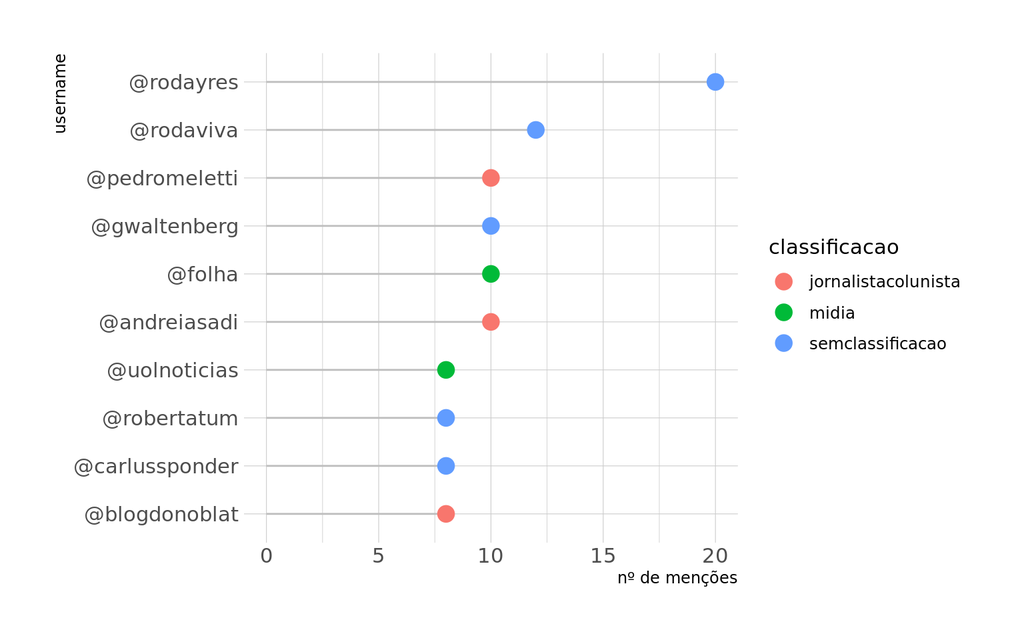

#### Os tweets com menções de maiores engajamentos

Abaixo é possível ver quais são os usuários mencionados nos tweets da senadora que dão mais engajamento:

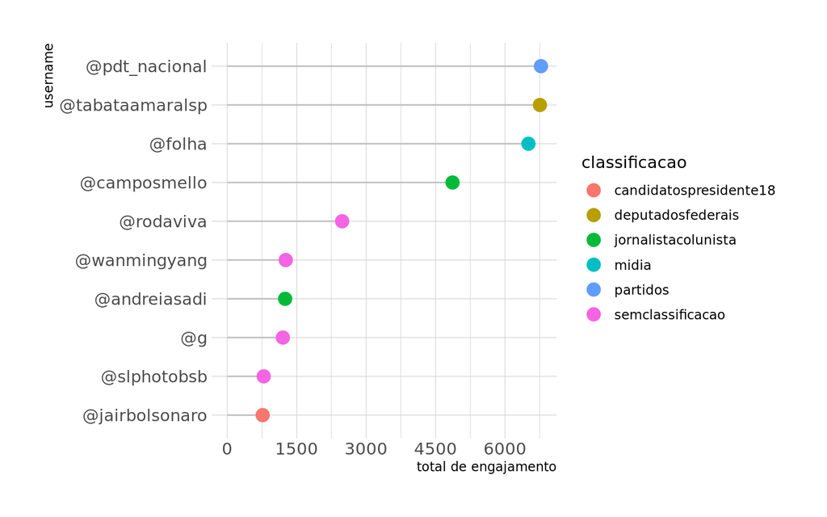

### Quem fala com Kátia

Também coletados os tweets dos usuários monitorados pelo Parlametria que mencionam a senadora. Ao todo, as menções totalizam 1000 tweeets.

#### Por tipo de usuário

Abaixo é possível ver o número de menções à senadora por tipo de usuário:

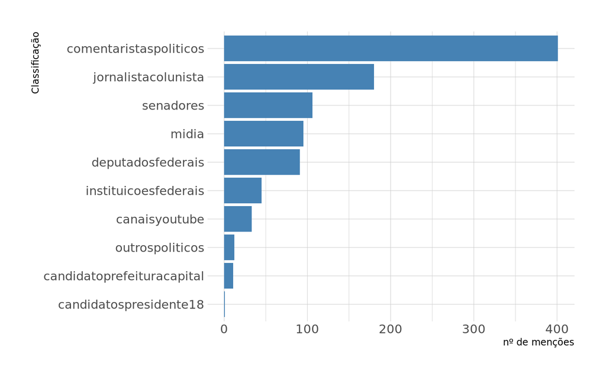

#### Os usuários que mais mencionam Kátia

Dentre os mais de 1.800 usuários monitorados, encontramos 256 que mencionaram a senadora em algum momento de 2019 pra cá. Abaixo listamos os usuários que mais mencionaram Kátia Abreu e a classificação de cada um.

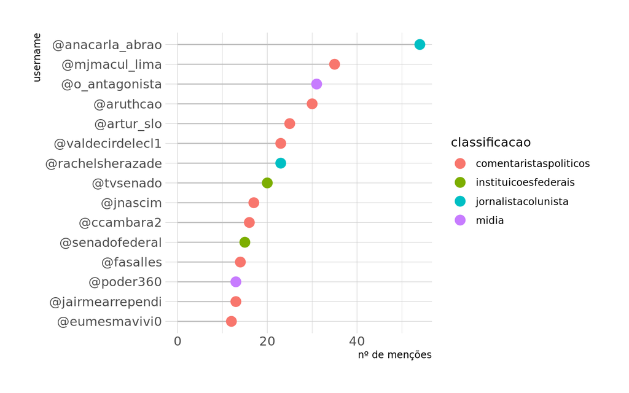

#### Menções que tiveram maior engajamento

Abaixo reunimos os usuários que mencionaram a senadora e tiveram grande repercussão em seus tweets, sendo o engajamento a soma de likes, replies e retweets.

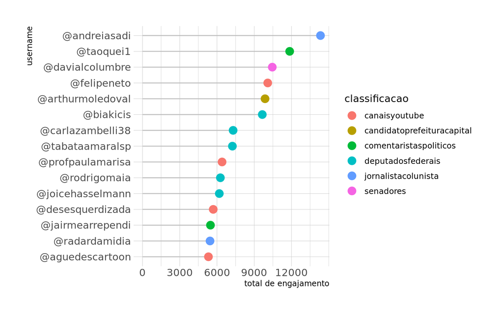

### Conteúdo dos tweets

| username | mencoes | data | text | engajamento | url | classificacao |
| --- | --- | --- | --- | --- | --- | --- |
| @andreiasadi | @katiaabreu | 18/05/2021 | “Sua memória não é boa”, de @KatiaAbreu a Ernesto Araujo. | 14335 | https://twitter.com/AndreiaSadi/status/1394671798420185094 | jornalistacolunista |
| @taoquei1 | @katiaabreu | 22/02/2021 | @KatiaAbreu Apaga não, deixa o vexame aí! Tá maravilhosoooooo. | 11853 | https://twitter.com/taoquei1/status/1363670507225309192 | comentaristaspoliticos |
| @taoquei1 | @katiaabreu | 28/03/2021 | @KatiaAbreu Aaahhhh Dona Kátia, desmentir a senhora não teve coragem né? Ficou muito claro pra geral que querem o Ernesto fora pra implementar o 5G da China! Não deu nem pra negar... Melhor fingir dem… | 11740 | https://twitter.com/taoquei1/status/1376303420689297409 | comentaristaspoliticos |
| @davialcolumbre | @katiaabreu; @senadofederal | 28/03/2021 | Meu incondicional apoio à presidente da comissão de Relações Exteriores do Senado,@KatiaAbreu A insinuação irresponsável por parte de um ministro não é somente um desrespeito ao @SenadoFederal.É um at… | 10453 | https://twitter.com/davialcolumbre/status/1376318013704667142 | senadores |
| @felipeneto | @katiaabreu | 12/06/2021 | Olá Senadora @KatiaAbreu - gostaria de saber o que a senhora pensa sobre o projeto de lei de licenciamento ambiental, já que será a relatora. Pq tá na hora da internet brasileira ficar sabendo de tudo… | 10086 | https://twitter.com/felipeneto/status/1403732392427261952 | canaisyoutube |
| @arthurmoledoval | @katiaabreu | 01/02/2019 | A @KatiaAbreu roubou a pasta da mesa diretora do senado para que “se cumpra o regimento“. Coerência mandou um abraço | 9870 | https://twitter.com/arthurmoledoval/status/1091485803899961345 | candidatoprefeituracapital;canaisyoutube;politico |
| @biakicis | @katiaabreu | 28/05/2021 | @KatiaAbreu Esqueça as vacas e os bezerros, vamos usar algo q só os humanos tem,a capacidade de pensar.A transparência nas eleições beneficia quem vence e traz paz social e muito mais legitimidade ao … | 9648 | https://twitter.com/Biakicis/status/1398260538703032320 | deputadosfederais |
| @davialcolumbre | @katiaabreu; @renancalheiros | 01/02/2019 | Nesse momento estou tentando presidir a reunião preparatória de eleição da Mesa, de forma legítima e regimental. Enquanto a senadora @KatiaAbreu a mando do senador @renancalheiros busca impedir autori… | 7912 | https://twitter.com/davialcolumbre/status/1091451390793256960 | senadores |
| @carlazambelli38 | @katiaabreu | 18/06/2019 | No Tocantins, a taxa de homicídios saltou de 16,58 em 2003 (antes do desarmamento) para 35,9 por 100 mil habitantes (mais que o dobro) em 2017. E a senadora @KatiaAbreu votou CONTRA a legítima defesa! | 7297 | https://twitter.com/CarlaZambelli38/status/1141102515687219202 | deputadosfederais |
| @tabataamaralsp | @katiaabreu | 02/10/2019 | Parabéns @KatiaAbreu pela coragem de votar a favor de uma reforma difícil, mas urgente e necessária. Não é óbvio, nem popular, contribuir de forma construtiva e tomar decisões baseadas em evidências, … | 7241 | https://twitter.com/tabataamaralsp/status/1179420838455582725 | deputadosfederais |

[output cut: 1430 more lines]